# aet

> Using the script **classification.py** we can run training of the classificator on the top of features. Using the schedule, we can apply exponential decay rule to the learning rate with parameter gamma (depend on epoch).

```python
!python classification.py --dataroot data --epochs 200 --schedule 100 150 --gamma 0.1 -c ./output_cls --net ./output/net_epoch_1499.pth --gpu-id 0
```

```
==> Preparing dataset cifar10
Files already downloaded and verified
    Total params: 2.46M

Epoch: [1 | 200] LR: 0.100000
Processing |################################| (391/391) Data: 0.002s | Batch: 0.062s | Total: 0:00:24 | ETA: 0:00:01 | Loss: 0.7548 | top1:  73.6480 | top5:  98.1080
Processing |################################| (100/100) Data: 0.003s | Batch: 0.028s | Total: 0:00:02 | ETA: 0:00:01 | Loss: 0.5316 | top1:  81.5100 | top5:  99.0700

Epoch: [2 | 200] LR: 0.100000
Processing |################################| (391/391) Data: 0.002s | Batch: 0.062s | Total: 0:00:24 | ETA: 0:00:01 | Loss: 0.5816 | top1:  79.7960 | top5:  99.0400
Processing |################################| (100/100) Data: 0.003s | Batch: 0.027s | Total: 0:00:02 | ETA: 0:00:01 | Loss: 0.4985 | top1:  82.6100 | top5:  99.2400

Epoch: [3 | 200] LR: 0.100000
Processing |################################| (391/391) Data: 0.002s | Batch: 0.067s | Total: 0:00:26 | ETA: 0:00:01 | Loss: 0.5325 | top1:  81.4300 | top5:  99.1320
Processing |################################| (100/100) Data: 0.003s | Batch: 0.028s | Total: 0:00:02 | ETA: 0:00:01 | Loss: 0.4671 | top1:  83.9200 | top5:  99.4100

Epoch: [4 | 200] LR: 0.100000
Processing |################################| (391/391) Data: 0.002s | Batch: 0.065s | Total: 0:00:25 | ETA: 0:00:01 | Loss: 0.4975 | top1:  82.6080 | top5:  99.2980
Processing |################################| (100/100) Data: 0.003s | Batch: 0.027s | Total: 0:00:02 | ETA: 0:00:01 | Loss: 0.4502 | top1:  84.4900 | top5:  99.4100

Epoch: [5 | 200] LR: 0.100000
Processing |################################| (391/391) Data: 0.002s | Batch: 0.064s | Total: 0:00:24 | ETA: 0:00:01 | Loss: 0.4775 | top1:  83.2720 | top5:  99.2980
Processing |################################| (100/100) Data: 0.003s | Batch: 0.027s | Total: 0:00:02 | ETA: 0:00:01 | Loss: 0.4463 | top1:  84.5900 | top5:  99.4900

Epoch: [6 | 200] LR: 0.100000
Processing |################################| (391/391) Data: 0.002s | Batch: 0.065s | Total: 0:00:25 | ETA: 0:00:01 | Loss: 0.4700 | top1:  83.4220 | top5:  99.4060
Processing |################################| (100/100) Data: 0.003s | Batch: 0.028s | Total: 0:00:02 | ETA: 0:00:01 | Loss: 0.4326 | top1:  85.1500 | top5:  99.5000

Epoch: [7 | 200] LR: 0.100000
Processing |################################| (391/391) Data: 0.002s | Batch: 0.065s | Total: 0:00:25 | ETA: 0:00:01 | Loss: 0.4535 | top1:  84.2220 | top5:  99.4220
Processing |################################| (100/100) Data: 0.003s | Batch: 0.027s | Total: 0:00:02 | ETA: 0:00:01 | Loss: 0.4374 | top1:  85.0700 | top5:  99.3300

Epoch: [8 | 200] LR: 0.100000
Processing |################################| (391/391) Data: 0.002s | Batch: 0.064s | Total: 0:00:25 | ETA: 0:00:01 | Loss: 0.4493 | top1:  84.1880 | top5:  99.4160
Processing |################################| (100/100) Data: 0.003s | Batch: 0.027s | Total: 0:00:02 | ETA: 0:00:01 | Loss: 0.4296 | top1:  85.5100 | top5:  99.4300

Epoch: [9 | 200] LR: 0.100000
Processing |################################| (391/391) Data: 0.002s | Batch: 0.065s | Total: 0:00:25 | ETA: 0:00:01 | Loss: 0.4407 | top1:  84.6400 | top5:  99.4600
Processing |################################| (100/100) Data: 0.003s | Batch: 0.027s | Total: 0:00:02 | ETA: 0:00:01 | Loss: 0.4413 | top1:  85.2300 | top5:  99.4100

```

[output cut: 750 more lines]

```
Processing |################################| (100/100) Data: 0.003s | Batch: 0.028s | Total: 0:00:02 | ETA: 0:00:01 | Loss: 0.3106 | top1:  90.0200 | top5:  99.7200

Epoch: [198 | 200] LR: 0.001000
Processing |################################| (391/391) Data: 0.002s | Batch: 0.065s | Total: 0:00:25 | ETA: 0:00:01 | Loss: 0.0932 | top1:  97.7080 | top5:  99.9820
Processing |################################| (100/100) Data: 0.003s | Batch: 0.027s | Total: 0:00:02 | ETA: 0:00:01 | Loss: 0.3107 | top1:  89.9700 | top5:  99.7000

Epoch: [199 | 200] LR: 0.001000
Processing |################################| (391/391) Data: 0.002s | Batch: 0.065s | Total: 0:00:25 | ETA: 0:00:01 | Loss: 0.0930 | top1:  97.7080 | top5:  99.9960
Processing |################################| (100/100) Data: 0.003s | Batch: 0.028s | Total: 0:00:02 | ETA: 0:00:01 | Loss: 0.3113 | top1:  89.8600 | top5:  99.6700

Epoch: [200 | 200] LR: 0.001000
Processing |################################| (391/391) Data: 0.002s | Batch: 0.065s | Total: 0:00:25 | ETA: 0:00:01 | Loss: 0.0941 | top1:  97.6320 | top5:  99.9920
Processing |################################| (100/100) Data: 0.004s | Batch: 0.029s | Total: 0:00:02 | ETA: 0:00:01 | Loss: 0.3123 | top1:  89.7500 | top5:  99.7000
Best acc:
90.02
```

> Visualization of training:

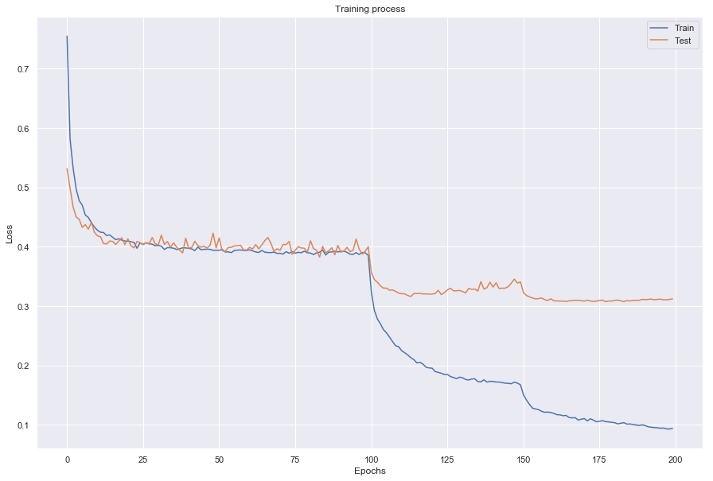

```python
logs = pd.read_csv('output_cls/log.txt', sep='\t').iloc[:, :-1]

plt.figure(figsize=(15, 10))
plt.plot(logs['Train Loss'], label='Train')
plt.plot(logs['Valid Loss'], label='Test')
plt.xlabel('Epochs')
plt.ylabel('Loss')
plt.title('Training process')
plt.legend()
```

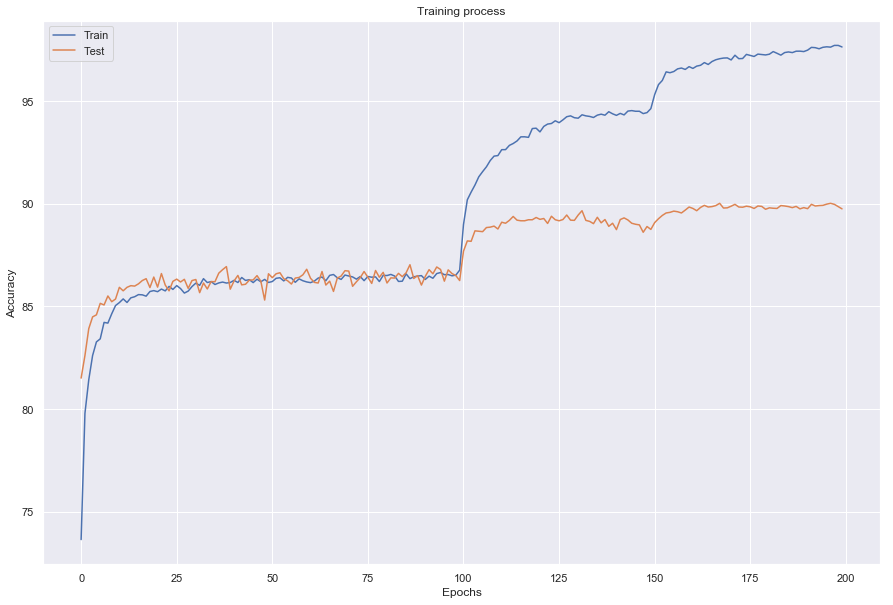

```python
plt.figure(figsize=(15, 10))
plt.plot(logs['Train Acc.'], label='Train')
plt.plot(logs['Valid Acc.'], label='Test')
plt.xlabel('Epochs')
plt.ylabel('Accuracy')
plt.title('Training process')
plt.legend()
```

> Conclusion: the training was succesfull and we can observe quick convergence. Accuracy gives the overall 90% on the test set. From 100 epoch we can observe boosting in training - learning rate is reduced.

# Episode II

> We changed the encoder to modified AlexNet architecture. Implementation is located in file AlexNet.py. Will train the own encoder-decoder scheme of affine transformations using the script of unsupervised training **main.py** :

```python
os.chdir('../affine_alexnet')
!ls
```

```
AlexNet.py                dataset.py                output_cls
NetworkInNetwork.py       distances-conv3.npy       pic.png
NonLinearClassifier.py    indexes-conv3.npy         utils
__pycache__               main.py                   vectors-alexnet-conv3.npy
classification.py         output
```

> Loss is MSE of $l_2$-norm between parameters of predicted and real affine transformation.

```python
!CUDA_VISIBLE_DEVICES=0 python main.py --cuda --outf ./output --dataroot data --lr 1e-4 --niter 100
```

```
Namespace(batchSize=512, cuda=True, dataroot='data', enlarge=1.3, imageSize=32, lr=0.0001, manualSeed=1814, net='', ngpu=1, niter=100, optimizer='', outf='./output', rot=180, shear=30, shrink=0.7, translate=0.2, workers=1)
Random Seed:  1814
Files already downloaded and verified
DataParallel(
  (module): Regressor(
    (Alexnet): AlexNet(
      (_feature_blocks): ModuleList(
        (0): Sequential(
          (0): Conv2d(3, 64, kernel_size=(3, 3), stride=(2, 2), padding=(1, 1))
          (1): BatchNorm2d(64, eps=1e-05, momentum=0.1, affine=True, track_running_stats=True)
          (2): ReLU(inplace)
        )
        (1): MaxPool2d(kernel_size=3, stride=2, padding=0, dilation=1, ceil_mode=False)
        (2): Sequential(
          (0): Conv2d(64, 192, kernel_size=(5, 5), stride=(1, 1), padding=(1, 1))
          (1): BatchNorm2d(192, eps=1e-05, momentum=0.1, affine=True, track_running_stats=True)
          (2): ReLU(inplace)
        )
        (3): MaxPool2d(kernel_size=3, stride=2, padding=0, dilation=1, ceil_mode=False)
        (4): Sequential(
          (0): Conv2d(192, 384, kernel_size=(3, 3), stride=(1, 1), padding=(1, 1))
          (1): BatchNorm2d(384, eps=1e-05, momentum=0.1, affine=True, track_running_stats=True)
          (2): ReLU(inplace)
        )
        (5): Sequential(
          (0): Conv2d(384, 256, kernel_size=(3, 3), stride=(1, 1), padding=(1, 1))
          (1): BatchNorm2d(256, eps=1e-05, momentum=0.1, affine=True, track_running_stats=True)
          (2): ReLU(inplace)
        )
        (6): Sequential(
          (0): Conv2d(256, 256, kernel_size=(3, 3), stride=(1, 1), padding=(1, 1))
          (1): BatchNorm2d(256, eps=1e-05, momentum=0.1, affine=True, track_running_stats=True)
          (2): ReLU(inplace)
        )
        (7): MaxPool2d(kernel_size=3, stride=2, padding=0, dilation=1, ceil_mode=False)
      )
    )
    (fc): Sequential(
      (0): Flatten()
      (1): Linear(in_features=512, out_features=256, bias=False)
```

[output cut: 91 more lines]

```
[85/100][0/98] Loss: 0.2489
[86/100][0/98] Loss: 0.2526
[87/100][0/98] Loss: 0.2469
[88/100][0/98] Loss: 0.2475
[89/100][0/98] Loss: 0.2518
[90/100][0/98] Loss: 0.2528
[91/100][0/98] Loss: 0.2492
[92/100][0/98] Loss: 0.2510
[93/100][0/98] Loss: 0.2418
[94/100][0/98] Loss: 0.2499
[95/100][0/98] Loss: 0.2474
[96/100][0/98] Loss: 0.2466
[97/100][0/98] Loss: 0.2472
[98/100][0/98] Loss: 0.2498
[99/100][0/98] Loss: 0.2426
```

> Will train own classificator on the top of AlexNet features:

```python
!python classification.py --dataroot data --epochs 100 --schedule 100 150 --gamma 0.3 --weight-decay 1e-10 -c ./output_cls --net ./output/net_epoch_99.pth --gpu-id 0 --lr 1e-2
```

```
==> Preparing dataset cifar10
Files already downloaded and verified
    Total params: 0.92M

Epoch: [1 | 100] LR: 0.010000
Processing |################################| (391/391) Data: 0.014s | Batch: 0.036s | Total: 0:00:14 | ETA: 0:00:01 | Loss: 2.1957 | top1:  27.4080 | top5:  77.5740
Processing |################################| (100/100) Data: 0.015s | Batch: 0.026s | Total: 0:00:02 | ETA: 0:00:01 | Loss: 2.1521 | top1:  32.5900 | top5:  80.2800

Epoch: [2 | 100] LR: 0.010000
Processing |################################| (391/391) Data: 0.013s | Batch: 0.034s | Total: 0:00:13 | ETA: 0:00:01 | Loss: 2.1176 | top1:  35.2500 | top5:  81.5300
Processing |################################| (100/100) Data: 0.014s | Batch: 0.025s | Total: 0:00:02 | ETA: 0:00:01 | Loss: 2.1297 | top1:  34.8500 | top5:  81.8500

Epoch: [3 | 100] LR: 0.010000
Processing |################################| (391/391) Data: 0.013s | Batch: 0.034s | Total: 0:00:13 | ETA: 0:00:01 | Loss: 2.0845 | top1:  38.4560 | top5:  82.6500
Processing |################################| (100/100) Data: 0.016s | Batch: 0.027s | Total: 0:00:02 | ETA: 0:00:01 | Loss: 2.0890 | top1:  38.8800 | top5:  81.5100

Epoch: [4 | 100] LR: 0.010000
Processing |################################| (391/391) Data: 0.015s | Batch: 0.037s | Total: 0:00:14 | ETA: 0:00:01 | Loss: 2.0626 | top1:  40.8600 | top5:  82.8280
Processing |################################| (100/100) Data: 0.016s | Batch: 0.028s | Total: 0:00:02 | ETA: 0:00:01 | Loss: 2.0686 | top1:  39.6600 | top5:  82.6700

Epoch: [5 | 100] LR: 0.010000
Processing |################################| (391/391) Data: 0.014s | Batch: 0.035s | Total: 0:00:13 | ETA: 0:00:01 | Loss: 2.0530 | top1:  41.5460 | top5:  82.5180
Processing |################################| (100/100) Data: 0.014s | Batch: 0.025s | Total: 0:00:02 | ETA: 0:00:01 | Loss: 2.1005 | top1:  35.7400 | top5:  79.1000

Epoch: [6 | 100] LR: 0.010000
Processing |################################| (391/391) Data: 0.014s | Batch: 0.035s | Total: 0:00:13 | ETA: 0:00:01 | Loss: 2.0418 | top1:  42.4160 | top5:  82.8080
Processing |################################| (100/100) Data: 0.015s | Batch: 0.027s | Total: 0:00:02 | ETA: 0:00:01 | Loss: 2.0604 | top1:  40.2000 | top5:  82.5200

Epoch: [7 | 100] LR: 0.010000
Processing |################################| (391/391) Data: 0.015s | Batch: 0.036s | Total: 0:00:14 | ETA: 0:00:01 | Loss: 2.0369 | top1:  42.6840 | top5:  82.9560
Processing |################################| (100/100) Data: 0.015s | Batch: 0.026s | Total: 0:00:02 | ETA: 0:00:01 | Loss: 2.0561 | top1:  40.6300 | top5:  81.8500

Epoch: [8 | 100] LR: 0.010000
Processing |################################| (391/391) Data: 0.013s | Batch: 0.034s | Total: 0:00:13 | ETA: 0:00:01 | Loss: 2.0288 | top1:  43.5080 | top5:  83.3380
Processing |################################| (100/100) Data: 0.015s | Batch: 0.026s | Total: 0:00:02 | ETA: 0:00:01 | Loss: 2.0379 | top1:  42.8300 | top5:  81.8300

Epoch: [9 | 100] LR: 0.010000
Processing |################################| (391/391) Data: 0.013s | Batch: 0.034s | Total: 0:00:13 | ETA: 0:00:01 | Loss: 2.0281 | top1:  43.6680 | top5:  82.9240
Processing |################################| (100/100) Data: 0.015s | Batch: 0.026s | Total: 0:00:02 | ETA: 0:00:01 | Loss: 2.0569 | top1:  40.5300 | top5:  82.0700

```

[output cut: 350 more lines]

```
Processing |################################| (100/100) Data: 0.012s | Batch: 0.023s | Total: 0:00:02 | ETA: 0:00:01 | Loss: 1.9976 | top1:  46.0600 | top5:  86.4800

Epoch: [98 | 100] LR: 0.010000
Processing |################################| (391/391) Data: 0.011s | Batch: 0.032s | Total: 0:00:12 | ETA: 0:00:01 | Loss: 1.9101 | top1:  55.1660 | top5:  86.5500
Processing |################################| (100/100) Data: 0.013s | Batch: 0.024s | Total: 0:00:02 | ETA: 0:00:01 | Loss: 1.9848 | top1:  47.1500 | top5:  85.8800

Epoch: [99 | 100] LR: 0.010000
Processing |################################| (391/391) Data: 0.011s | Batch: 0.031s | Total: 0:00:12 | ETA: 0:00:01 | Loss: 1.9062 | top1:  55.5100 | top5:  86.5240
Processing |################################| (100/100) Data: 0.013s | Batch: 0.023s | Total: 0:00:02 | ETA: 0:00:01 | Loss: 1.9896 | top1:  46.6900 | top5:  86.8300

Epoch: [100 | 100] LR: 0.010000
Processing |################################| (391/391) Data: 0.011s | Batch: 0.032s | Total: 0:00:12 | ETA: 0:00:01 | Loss: 1.9047 | top1:  55.6200 | top5:  86.5680
Processing |################################| (100/100) Data: 0.013s | Batch: 0.023s | Total: 0:00:02 | ETA: 0:00:01 | Loss: 1.9907 | top1:  46.5600 | top5:  86.8600
Best acc:
47.91
```

> Unfortunantly, the training on the top of pretrained AlexNet using the AET method doesn't demonstrited the effectivity. We are analyzing this situation. We tested the different options of learning rate, gamma and weight decay in $l_2$ norm, but we still haven't finished fixing this issue. Maybe, the AlexNet architecture isn't appropriate for this task. Anyway, we will visualize the features and find the closest neighbors of randomly chosen pictures from test set.

> Visualize the features and find the closest neighbors of randomly chosen pictures from test set:

```python
from AlexNet import Regressor

class Flatten(nn.Module):
    def __init__(self):
        super(Flatten, self).__init__()

    def forward(self, feat):
        return feat.view(feat.size(0), -1)

class PretrainedModel(nn.Module):
    def __init__(self, out_feat_key):

        super(PretrainedModel, self).__init__()
        self.output_layer = [out_feat_key]

        weights_dict = torch.load('output/net_epoch_99.pth', map_location='cpu')

        modified_weights = OrderedDict()
        for x, y in zip(weights_dict.keys(), weights_dict.values()):
            modified_weights[x[7:]] = y

        self.pretrained_model = Regressor(6)
        self.pretrained_model.load_state_dict(modified_weights)
        self.pretrained_model = self.pretrained_model.Alexnet

        self.flatten = Flatten()

    def forward(self, x):

        output = self.pretrained_model(x, self.output_layer)
        output = self.flatten(output)

        return output
```

```python
obj = PretrainedModel('conv3')
```

```python
obj
```

```
PretrainedModel(
  (pretrained_model): AlexNet(
    (_feature_blocks): ModuleList(
      (0): Sequential(
        (0): Conv2d(3, 64, kernel_size=(3, 3), stride=(2, 2), padding=(1, 1))
        (1): BatchNorm2d(64, eps=1e-05, momentum=0.1, affine=True, track_running_stats=True)
        (2): ReLU(inplace)
      )
      (1): MaxPool2d(kernel_size=3, stride=2, padding=0, dilation=1, ceil_mode=False)
      (2): Sequential(
        (0): Conv2d(64, 192, kernel_size=(5, 5), stride=(1, 1), padding=(1, 1))
        (1): BatchNorm2d(192, eps=1e-05, momentum=0.1, affine=True, track_running_stats=True)
        (2): ReLU(inplace)
      )
      (3): MaxPool2d(kernel_size=3, stride=2, padding=0, dilation=1, ceil_mode=False)
      (4): Sequential(
        (0): Conv2d(192, 384, kernel_size=(3, 3), stride=(1, 1), padding=(1, 1))
        (1): BatchNorm2d(384, eps=1e-05, momentum=0.1, affine=True, track_running_stats=True)
        (2): ReLU(inplace)
      )
      (5): Sequential(
        (0): Conv2d(384, 256, kernel_size=(3, 3), stride=(1, 1), padding=(1, 1))
        (1): BatchNorm2d(256, eps=1e-05, momentum=0.1, affine=True, track_running_stats=True)
        (2): ReLU(inplace)
      )
      (6): Sequential(
        (0): Conv2d(256, 256, kernel_size=(3, 3), stride=(1, 1), padding=(1, 1))
        (1): BatchNorm2d(256, eps=1e-05, momentum=0.1, affine=True, track_running_stats=True)
        (2): ReLU(inplace)
      )
      (7): MaxPool2d(kernel_size=3, stride=2, padding=0, dilation=1, ceil_mode=False)
    )
  )
  (flatten): Flatten()
)
```

```python
transform = transforms.Compose([
                               transforms.ToTensor()
                           ])

trainset = torchvision.datasets.CIFAR10(root='./data', train=True,
                                        download=True, transform=transform)
trainloader = torch.utils.data.DataLoader(trainset, batch_size=1,
                                          shuffle=False, num_workers=2)

testset = torchvision.datasets.CIFAR10(root='./data', train=False,
                                       download=True, transform=transform)
testloader = torch.utils.data.DataLoader(testset, batch_size=1,
                                         shuffle=False, num_workers=2)

classes = ('plane', 'car', 'bird', 'cat',
           'deer', 'dog', 'frog', 'horse', 'ship', 'truck')
```

```
Files already downloaded and verified
Files already downloaded and verified
```

```python
%%time

vectors = []

for image, label in testset:

    vector = obj(image.expand(1, 3, 32, 32).cuda()).cpu().detach().numpy()
    vectors.append(vector)

vectors = np.squeeze(np.array(vectors))

torch.save(torch.Tensor(vectors), '../../vectors/vectors_alexnet_conv3.pth')
```

```
CPU times: user 10.3 s, sys: 419 ms, total: 10.7 s
Wall time: 14.6 s
```

```python
%%time

n_neighbors = 5

knn = KDTree(vectors)
distances, indexes = knn.query(vectors, n_neighbors)

np.save('distances-conv3.npy', distances)
np.save('indexes-conv3.npy', indexes)
```

```
CPU times: user 5min 37s, sys: 267 ms, total: 5min 38s
Wall time: 5min 39s
```

```python
indexes = np.load('indexes-conv3.npy')
```

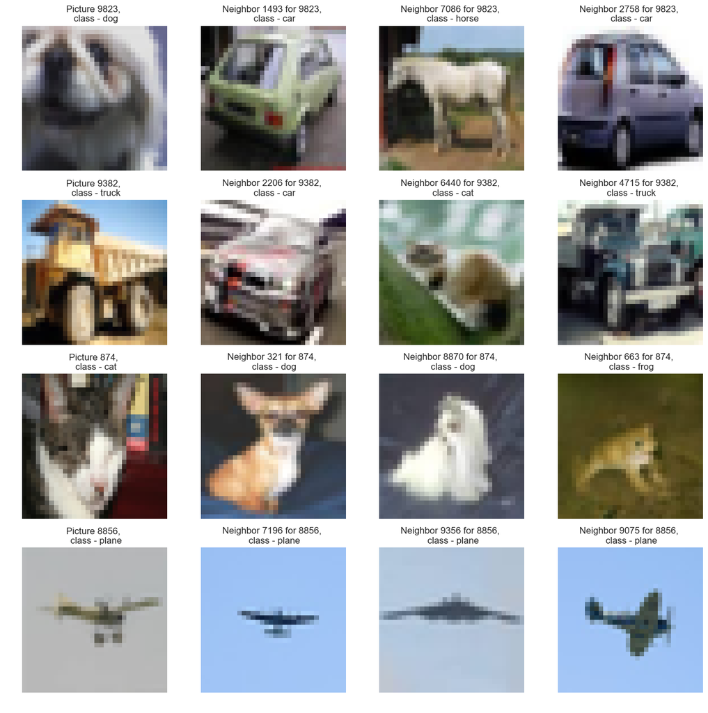

```python
plot_examples_knn(testset, indexes)
```